# Country vs Post

Yang Xu

11/28/2016

## Dataset processing

In order to work on identify forum activity pattern for different countries, subset (contains all nonnul country values) is used for the following analysis.

For this specific dataset, all the variables related to forumviews are zero contains no information. So I removed all these variables to clean the data.

The subset I used to discover post related pattern contains following variables:

‘IPCountryName’ ,‘AnyLectureActivity’,‘PercentWeeksActiveInForum’,‘TotalForumComments’,‘TotalForumPosts’ ,‘Comments.1’,‘Comments.2’, ‘Comments.3’, ‘Comments.4’, ‘Comments.5’, ‘Comments.6’, ‘Comments.7’, ‘Comments.8’,‘Posts.1’,‘Posts.2’,‘Posts.3’,‘Posts.4’,‘Posts.5’,‘Posts.6’,‘Posts.7’,‘Posts.8’,‘TotalEvents’,‘NumActiveDays’

## Details

### Correlation Check

First let’s check on the correlations between variables. The following graph is a visualization on lower triangle of the correlation matrix. Deeper color shade indicates stronger correlation between two varibles. Color red indicates negative correlation while navy stands for positive correlation.

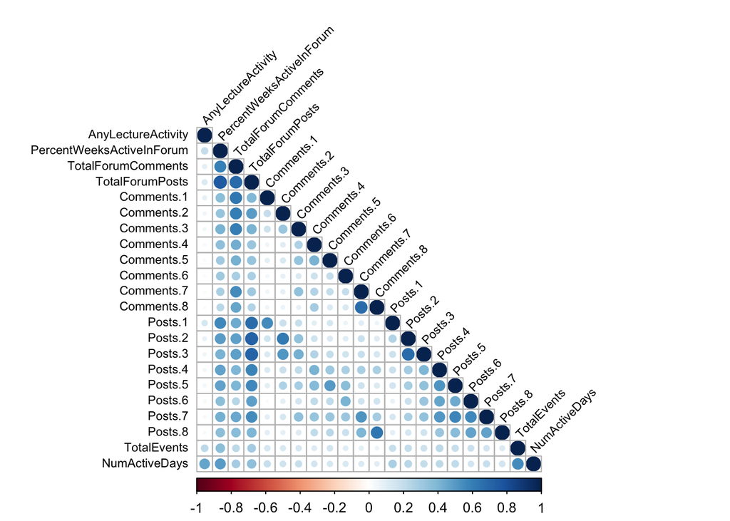

### Country with most students

Table of 20 countries with most enrolled students:

```
##
##            Romania             Poland            Ukraine
##                141                151                154
##           Portugal              Italy          Singapore
##                159                161                165
##        Philippines             Greece              China
##                170                178                180
##             Mexico           Colombia            Germany
##                194                204                299
##          Australia              Spain Russian Federation
##                324                350                399
##             Canada             Brazil     United Kingdom
##                549                605                628
##              India      United States
##                861               5791
```

Let’s take a look at varibles distributions by country.

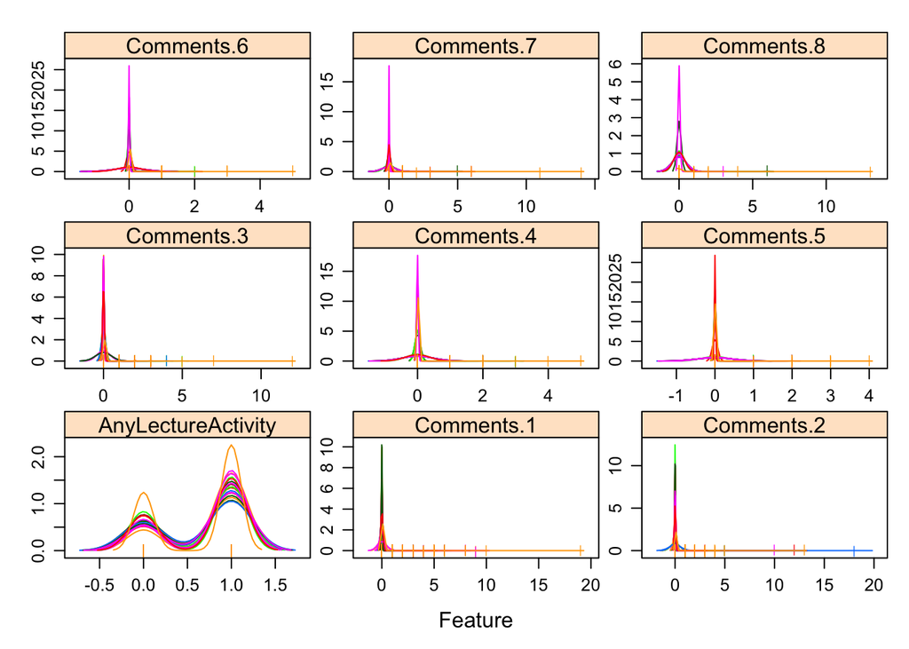

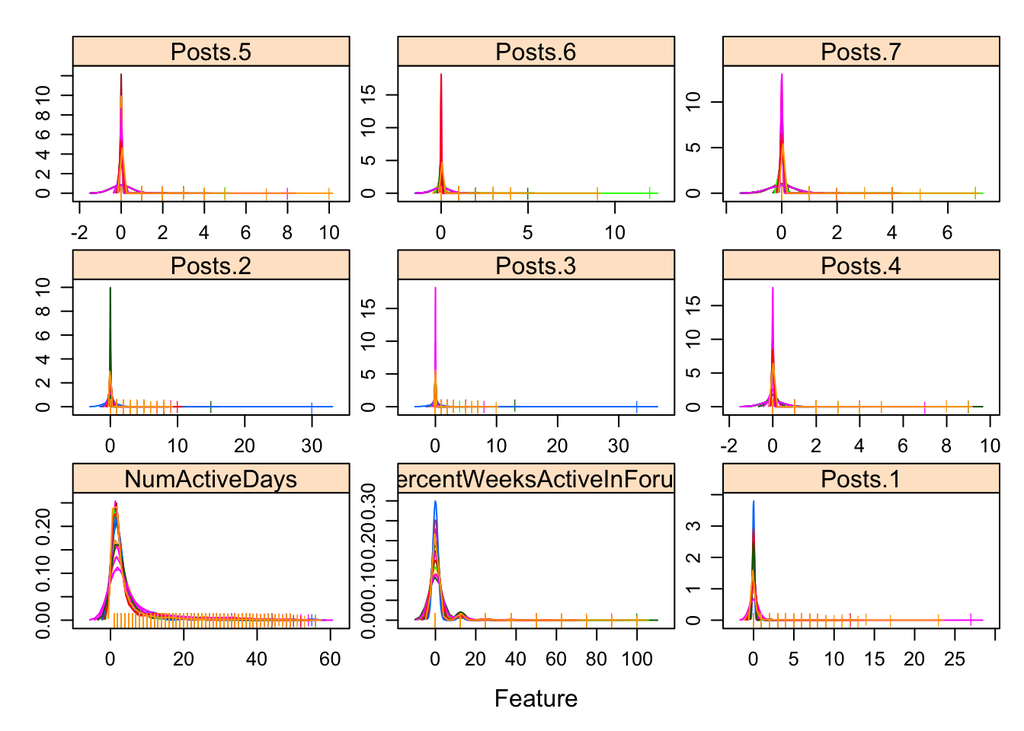

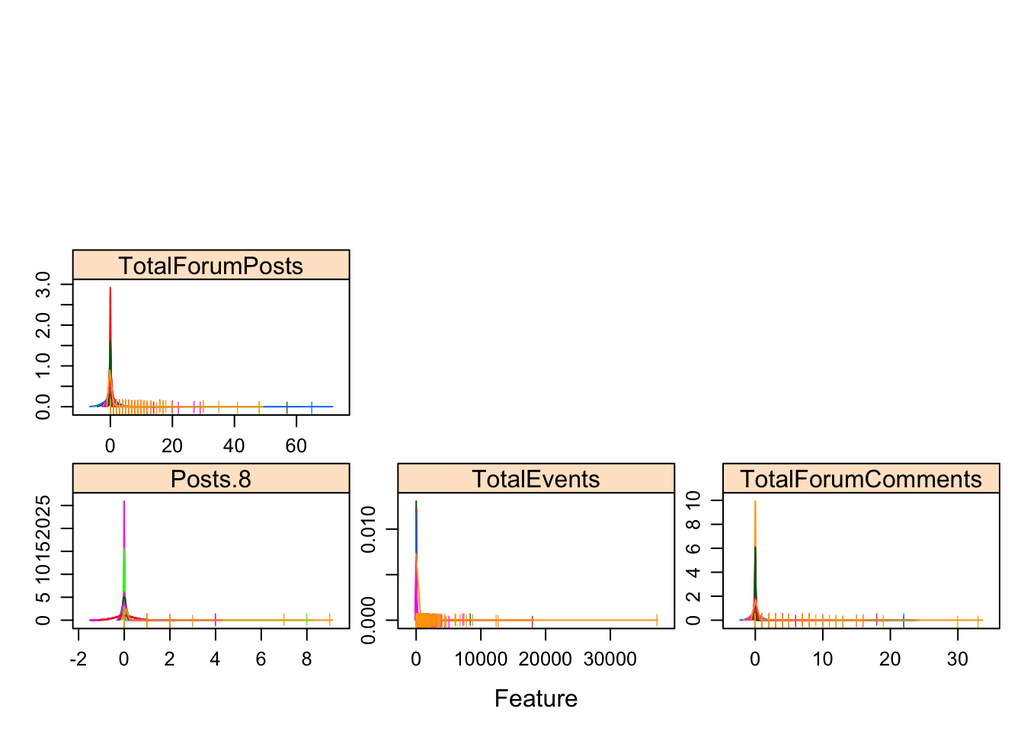

The plots above show out the distribution for each variable while different colors mean different countries. They give us a general idea about the dataset. The count of most of forum related activities is zero no matter which country it is. Comparing with comments data from other weeks, week 8 seems to have a different distribution.

## Graph

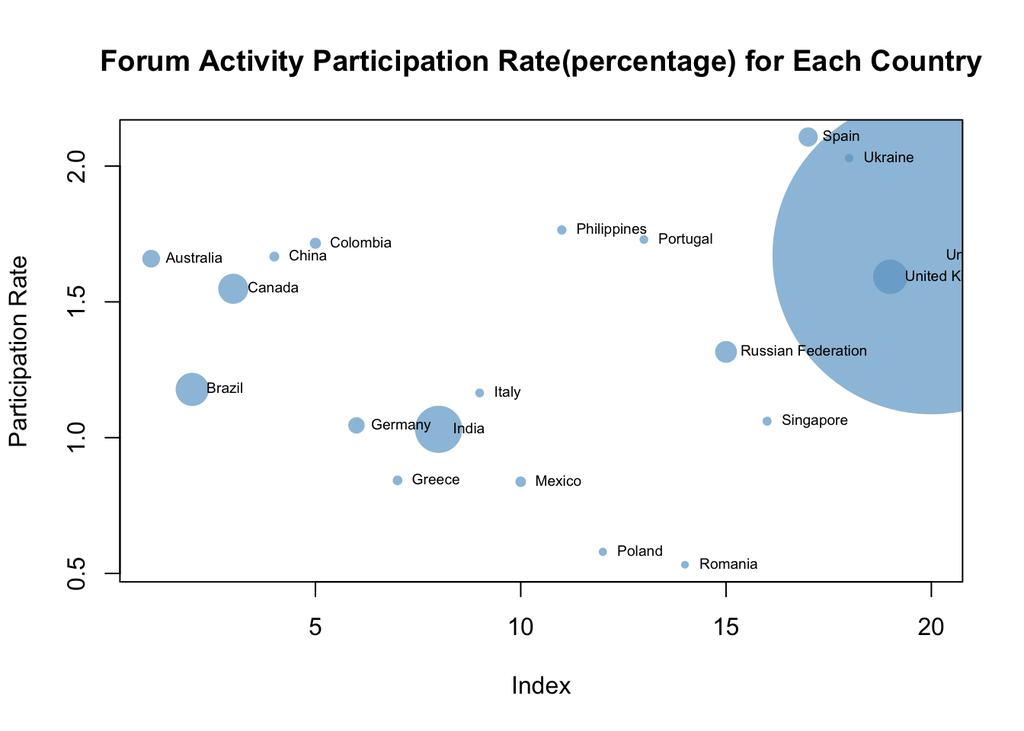

**Quantitles Visualization**

Let’s look at the quantitles in detail.

```
##        0%       25%       50%       75%      100%
## 0.5319149 1.0415574 1.4320295 1.6819435 2.1071429
```

### Post & Comments

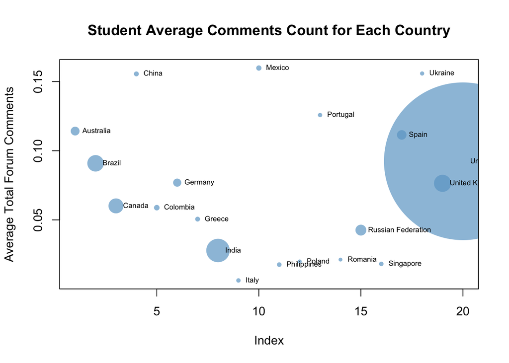

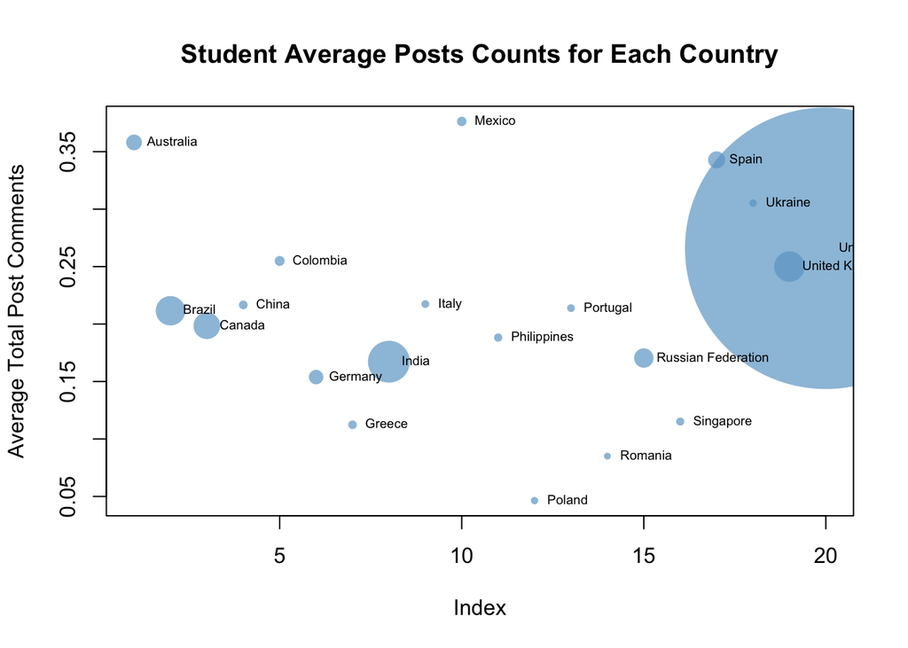

## Test

### Method

Multi kruskal Test is used to test for if they were from the same distribution. If the P value is less than 0.05 we reject the null hypothesis and say that the pattern for specfic variables differ by country.

```
## $AnyLectureActivity
##
##  Kruskal-Wallis rank sum test
##
## data:  AnyLectureActivity by IPCountryName
## Kruskal-Wallis chi-squared = 11659, df = 167, p-value < 2.2e-16
##
##
## $PercentWeeksActiveInForum
##
##  Kruskal-Wallis rank sum test
##
## data:  PercentWeeksActiveInForum by IPCountryName
## Kruskal-Wallis chi-squared = 1276.5, df = 167, p-value < 2.2e-16
##
##
## $TotalForumComments
##
##  Kruskal-Wallis rank sum test
##
## data:  TotalForumComments by IPCountryName
## Kruskal-Wallis chi-squared = 715.54, df = 167, p-value < 2.2e-16
##
##
## $TotalForumPosts
##
##  Kruskal-Wallis rank sum test
##
## data:  TotalForumPosts by IPCountryName
## Kruskal-Wallis chi-squared = 1210.9, df = 167, p-value < 2.2e-16
##
##
## $Comments.1
##
##  Kruskal-Wallis rank sum test
##
## data:  Comments.1 by IPCountryName
## Kruskal-Wallis chi-squared = 484.55, df = 167, p-value < 2.2e-16
##
##
```

[output cut: 119 more lines]

```
##
## $TotalEvents
##
##  Kruskal-Wallis rank sum test
##
## data:  TotalEvents by IPCountryName
## Kruskal-Wallis chi-squared = 19747, df = 167, p-value < 2.2e-16
##
##
## $NumActiveDays
##
##  Kruskal-Wallis rank sum test
##
## data:  NumActiveDays by IPCountryName
## Kruskal-Wallis chi-squared = 20045, df = 167, p-value < 2.2e-16
```

### Result

From the test result, only var Posts.5 (posts number for week 5) have nonsignificant p-values.

In other words, the distributions of other forum related variables for different countries are not the same.